# Imports and connections

В данном разделе импортируем все библиотеки которые будем использовать, а также обычно подключаемся

Dataset возьмем с Kaggle. К Kaggle можно подключаться через api и эффективно скачивать датасеты, однако тут мы делать этого не будем

Tutorial:https://saturncloud.io/blog/how-to-import-kaggle-datasets-into-jupyter-notebook/

```python
from catboost import CatBoostRegressor
from sklearn.model_selection import train_test_split
from sklearn.metrics import mean_squared_error
from datetime import datetime

import pandas as pd
import numpy as np
import re
```

# Data load

https://www.kaggle.com/datasets/felixzhao/productdemandforecasting - ссылка на датасет

Скачиваем csv и считываем при помощи pandas

```python
name_dataset_file = 'Historical Product Demand.csv'

df = pd.read_csv(name_dataset_file)
df.head(5)
```

|  | Product_Code | Warehouse | Product_Category | Date | Order_Demand |
| --- | --- | --- | --- | --- | --- |
| 0 | Product_0993 | Whse_J | Category_028 | 2012/7/27 | 100 |
| 1 | Product_0979 | Whse_J | Category_028 | 2012/1/19 | 500 |
| 2 | Product_0979 | Whse_J | Category_028 | 2012/2/3 | 500 |
| 3 | Product_0979 | Whse_J | Category_028 | 2012/2/9 | 500 |
| 4 | Product_0979 | Whse_J | Category_028 | 2012/3/2 | 500 |

# DA

Посмотрим сколько у нас уникальных товаров, точек продажи, категорий товаров

```python
df['Product_Code'].unique().shape[0]
```

```
2160
```

```python
df['Warehouse'].unique().shape[0]
```

```
4
```

```python
df['Product_Category'].unique().shape[0]
```

```
33
```

Почистим date

```python
df['Date'].isna().sum() / df['Date'].shape[0]
```

```
0.010718355863910546
```

```python
df = df.dropna(subset = ['Date'])
```

```python
df.isna().sum()
```

```
Product_Code        0
Warehouse           0
Product_Category    0
Date                0
Order_Demand        0
dtype: int64
```

```python
df.dtypes
```

```
Product_Code        object
Warehouse           object
Product_Category    object
Date                object
Order_Demand        object
dtype: object
```

Прежде чем использовать ниженаписанную функцию попробуйте просто использовать astype(int) и разберитесь в чем тут проблема и зачем тут эта функция

```python
# def convert_target(x):
#     try:
#         return int(x)
#     except:
#         return int(re.sub("[^0-9]", "", x))

#df['Order_Demand'] = df['Order_Demand'].apply(lambda x: convert_target(x)) #astype(float)

df['Order_Demand'] = df['Order_Demand'].astype(str)
```

Посмотрим что там у нас с временным промежутком в данных

```python
df['Date'] = pd.to_datetime(df['Date']).astype(object)
print(df['Date'].min())
print(df['Date'].max())
```

```
2011-01-08 00:00:00
2017-01-09 00:00:00
```

# Feature engineering

Из 4 представленных признаков мало что можно понять

Немного подумав можно понять что количество тех или иных заказываемых товаров могло изменяться от года к году. А также от сезона.

Т.к. модель не поймет datetime если вы его ей отдадите в виде datetime, займемся feature engineering и построим несколько новых фичей

Достанем год и месяц

```python
df['year'] = df['Date'].apply(lambda x: x.year)
```

```python
df['month'] = df['Date'].apply(lambda x: x.month)
```

Создадим сезон

```python
def get_season(x):
    seasons = {1:'winter',
               2:'winter',
               3:'spring',
               4:'spring',
               5:'spring',
               6:'summer',
               7:'summer',
               8:'summer',
               9:'fall',
              10:'fall',
              11:'fall',
              12:'winter'}
    return seasons[x]

df['season'] = df['month'].apply(get_season)
df
```

|  | Product_Code | Warehouse | Product_Category | Date | Order_Demand | year | month | season |
| --- | --- | --- | --- | --- | --- | --- | --- | --- |
| 0 | Product_0993 | Whse_J | Category_028 | 2012-07-27 00:00:00 | 100 | 2012 | 7 | summer |
| 1 | Product_0979 | Whse_J | Category_028 | 2012-01-19 00:00:00 | 500 | 2012 | 1 | winter |
| 2 | Product_0979 | Whse_J | Category_028 | 2012-02-03 00:00:00 | 500 | 2012 | 2 | winter |
| 3 | Product_0979 | Whse_J | Category_028 | 2012-02-09 00:00:00 | 500 | 2012 | 2 | winter |
| 4 | Product_0979 | Whse_J | Category_028 | 2012-03-02 00:00:00 | 500 | 2012 | 3 | spring |
| ... | ... | ... | ... | ... | ... | ... | ... | ... |
| 1048570 | Product_1791 | Whse_J | Category_006 | 2016-04-27 00:00:00 | 1000 | 2016 | 4 | spring |
| 1048571 | Product_1974 | Whse_J | Category_006 | 2016-04-27 00:00:00 | 1 | 2016 | 4 | spring |
| 1048572 | Product_1787 | Whse_J | Category_006 | 2016-04-28 00:00:00 | 2500 | 2016 | 4 | spring |
| 1048573 | Product_0901 | Whse_J | Category_023 | 2016-10-07 00:00:00 | 50 | 2016 | 10 | fall |
| 1048574 | Product_0704 | Whse_J | Category_001 | 2016-06-27 00:00:00 | 4 | 2016 | 6 | summer |

1037336 rows × 8 columns

Достанем

день с начала месяца

день с начала года

и конвертируем дату в числовой тип

```python
df['day_from_month'] = df['Date'].apply(lambda x: x.day)
df['day_from_year'] = df['Date'].apply(lambda x: x.dayofyear)
df['date_int_convert'] = df['Date'].apply(lambda x: int(x.timestamp()))
```

Однако наши дни в месяце а также дни в году цикличны

А мы с Вами знаем прекрасные математические функции которые имеют такую же цикличность

Сделаем цикличность некоторых временных признаков

Вопрос на погуглить: а зачем это делают?

```python
df['sin_day_month'] = np.sin(df['day_from_month']*(2.*np.pi/30))
df['sin_day_year'] = np.sin(df['day_from_month']*(2.*np.pi/365))
```

```python
df
```

|  | Product_Code | Warehouse | Product_Category | Date | Order_Demand | year | month | season | day_from_month | day_from_year | date_int_convert | sin_day_month | sin_day_year |
| --- | --- | --- | --- | --- | --- | --- | --- | --- | --- | --- | --- | --- | --- |
| 0 | Product_0993 | Whse_J | Category_028 | 2012-07-27 00:00:00 | 100 | 2012 | 7 | summer | 27 | 209 | 1343347200 | -0.587785 | 0.448229 |
| 1 | Product_0979 | Whse_J | Category_028 | 2012-01-19 00:00:00 | 500 | 2012 | 1 | winter | 19 | 19 | 1326931200 | -0.743145 | 0.321270 |
| 2 | Product_0979 | Whse_J | Category_028 | 2012-02-03 00:00:00 | 500 | 2012 | 2 | winter | 3 | 34 | 1328227200 | 0.587785 | 0.051620 |
| 3 | Product_0979 | Whse_J | Category_028 | 2012-02-09 00:00:00 | 500 | 2012 | 2 | winter | 9 | 40 | 1328745600 | 0.951057 | 0.154309 |
| 4 | Product_0979 | Whse_J | Category_028 | 2012-03-02 00:00:00 | 500 | 2012 | 3 | spring | 2 | 62 | 1330646400 | 0.406737 | 0.034422 |
| ... | ... | ... | ... | ... | ... | ... | ... | ... | ... | ... | ... | ... | ... |
| 1048570 | Product_1791 | Whse_J | Category_006 | 2016-04-27 00:00:00 | 1000 | 2016 | 4 | spring | 27 | 118 | 1461715200 | -0.587785 | 0.448229 |
| 1048571 | Product_1974 | Whse_J | Category_006 | 2016-04-27 00:00:00 | 1 | 2016 | 4 | spring | 27 | 118 | 1461715200 | -0.587785 | 0.448229 |
| 1048572 | Product_1787 | Whse_J | Category_006 | 2016-04-28 00:00:00 | 2500 | 2016 | 4 | spring | 28 | 119 | 1461801600 | -0.406737 | 0.463550 |
| 1048573 | Product_0901 | Whse_J | Category_023 | 2016-10-07 00:00:00 | 50 | 2016 | 10 | fall | 7 | 281 | 1475798400 | 0.994522 | 0.120208 |
| 1048574 | Product_0704 | Whse_J | Category_001 | 2016-06-27 00:00:00 | 4 | 2016 | 6 | summer | 27 | 179 | 1466985600 | -0.587785 | 0.448229 |

1037336 rows × 13 columns

# Catboost

Закончив вертеть данные перейдем наконец-то к модели

Название CatBoost произошло (нет не от котиков) а от Cat-Categorical. Данная библиотека позволяет конвертировать и обрабатывать самостоятельно categorical features что является ее основным преимуществом

Создадим три списка,

1. Список категориальных фичей
2. Список все фичей которые будут задействованы в обучении
3. Список target-ов (то что мы предсказываем)

```python
CAT_FEATURES = ['Product_Code',
                'Warehouse',
                'Product_Category',
                'season',
                'month',
                'year']

FEATURES = ['Product_Code',
                'Warehouse',
                'Product_Category',
                'season',
                'month',
                'year',
                'sin_day_month',
                'sin_day_year',
                'date_int_convert']


TARGET = ['Order_Demand']
```

Произведем разбиение на обучающую и тестовую выборку при помощи метода train test split

Но важнее здесь другое: а именно **стратификация**

Процедура стратификации позволяет разделить наши данные так, чтобы и в обучающую и в тестовую выборку данные попали распределившись согласно test_size по стратифицирующей колонке.

(Представим себе ситуацию что у нас есть 4 красных шарика и 6 желтых). Всего 10 шариков. И мы хотим чтобы наши шарики распределились в соотношении 50 / 50. Стратификация по цвету в данном случае разобьет каждую группу цвета в соотношении 50/50 и предотвратит ситуацию когда в одну из выборок попадут шары одного цвета.

Вопрос на погуглить: а что делают с непрерывными признаками?

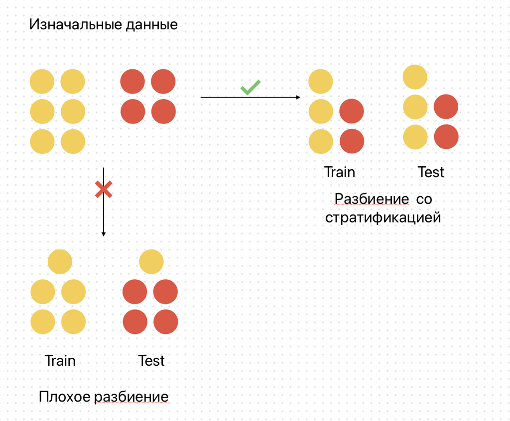

Подготовимся к стратификации и создадим колонку из года + месяца

```python
df['stratify_column'] = df['year'].astype(str) + '-' + df['month'].astype(str)
```

Разберитесь с ошибкой

```python
X_train, X_test, y_train, y_test = train_test_split(df[FEATURES],
                                                    df[TARGET],
                                                    test_size=0.33,
                                                    random_state=42,
                                                    stratify = df['stratify_column'])
```

[output not shown]

[output cut: 10 more lines]

[output not shown]

Решение ошибки:

```python
check_count_stratify = df['stratify_column'].value_counts().to_dict()
check_count_stratify
```

```
{'2013-10': 24546,
 '2014-3': 19839,
 '2014-10': 19579,
 '2015-7': 19127,
 '2015-3': 19122,
 '2013-7': 19085,
 '2014-9': 18970,
 '2013-9': 18946,
 '2014-7': 18867,
 '2013-11': 18617,
 '2012-3': 18604,
 '2012-10': 18515,
 '2015-6': 18413,
 '2015-1': 18245,
 '2014-2': 18214,
 '2012-2': 18123,
 '2015-2': 18116,
 '2014-4': 18077,
 '2014-1': 18013,
 '2013-5': 17786,
 '2015-10': 17785,
 '2014-6': 17762,
 '2012-7': 17718,
 '2013-4': 17685,
 '2015-4': 17603,
 '2014-11': 17486,
 '2012-11': 17416,
 '2013-12': 17398,
 '2013-3': 17397,
 '2016-11': 17335,
 '2015-11': 17335,
 '2016-3': 17282,
 '2013-2': 17119,
 '2012-5': 17014,
 '2014-12': 16937,
 '2012-6': 16911,
 '2013-8': 16660,
 '2015-9': 16656,
 '2014-5': 16639,
 '2013-1': 16638,
```

[output cut: 13 more lines]

```
 '2016-8': 15333,
 '2016-7': 15319,
 '2016-4': 15223,
 '2016-12': 15036,
 '2012-12': 15025,
 '2016-1': 14515,
 '2016-5': 14487,
 '2011-12': 598,
 '2017-1': 53,
 '2011-11': 31,
 '2011-9': 4,
 '2011-10': 3,
 '2011-6': 2,
 '2011-1': 1,
 '2011-5': 1}
```

Обьединим сезоны в которых мало записей в "другие"

```python
df['stratify_column'] = df['stratify_column'].apply(lambda x: 'other' if check_count_stratify[x] < 5 else x)
```

Теперь разобьем наши данные на train и validation

Test же возьмем из последних лет (а именно тех данных за последние годы (Ведь мы хотим предсказывать будущее а не прошлое)

```python
X_train, X_eval, y_train, y_eval = train_test_split(df[df['year'] < 2016][FEATURES],
                                                    df[df['year'] < 2016][TARGET],
                                                    test_size=0.33,
                                                    random_state=42,
                                                    stratify = df[df['year'] < 2016]['stratify_column'])
```

```python
test = df[df['year'] >= 2016]
X_test = test[FEATURES]
y_test = test[TARGET]
```

При объявлении модели зададим несколько параметров (их называют гиперпараметры)

Почитать за что они отвечают можно в офиц. документации

https://catboost.ai/en/docs/concepts/python-reference_catboostregressor

https://catboost.ai/en/docs/concepts/python-reference_catboostregressor_fit#eval_set

```python
model = CatBoostRegressor(iterations=10000,
                          learning_rate=1**(-2),
                          loss_function='RMSE',
                          cat_features=CAT_FEATURES,
                          depth=4)
# Fit model
model.fit(X_train,
          y_train,
          eval_set = (X_eval, y_eval),
          early_stopping_rounds=1000,
          verbose=100,
          plot=True)

# Get predictions
preds = model.predict(X_test)
```

```
MetricVisualizer(layout=Layout(align_self='stretch', height='500px'))
```

```
0:	learn: 27889.8588917	test: 26873.3253298	best: 26873.3253298 (0)	total: 50.6ms	remaining: 8m 26s
100:	learn: 27295.6888425	test: 26389.2662688	best: 26379.8940997 (97)	total: 3.7s	remaining: 6m 2s
200:	learn: 27078.7702388	test: 26312.7477841	best: 26312.7477841 (200)	total: 7.59s	remaining: 6m 9s
300:	learn: 26951.4304776	test: 26301.9382215	best: 26281.7882486 (253)	total: 11.7s	remaining: 6m 16s
400:	learn: 26856.3941540	test: 26286.0286200	best: 26275.7632406 (383)	total: 16s	remaining: 6m 21s
500:	learn: 26747.9101838	test: 26271.1590427	best: 26253.3902214 (490)	total: 20.3s	remaining: 6m 25s
600:	learn: 26600.5398207	test: 26279.2625116	best: 26253.3902214 (490)	total: 24.6s	remaining: 6m 25s
700:	learn: 26517.4586232	test: 26297.1657548	best: 26253.3902214 (490)	total: 28.8s	remaining: 6m 22s
800:	learn: 26424.0774583	test: 26287.6329709	best: 26253.3902214 (490)	total: 33.2s	remaining: 6m 21s
900:	learn: 26319.8453762	test: 26387.9941211	best: 26253.3902214 (490)	total: 37.3s	remaining: 6m 16s
1000:	learn: 26252.0674315	test: 26401.6694172	best: 26253.3902214 (490)	total: 41.8s	remaining: 6m 15s
1100:	learn: 26196.8964445	test: 26357.8361294	best: 26253.3902214 (490)	total: 45.8s	remaining: 6m 9s
1200:	learn: 26150.8353400	test: 26356.7209917	best: 26253.3902214 (490)	total: 50s	remaining: 6m 6s
1300:	learn: 26110.4107961	test: 26367.1391040	best: 26253.3902214 (490)	total: 54.2s	remaining: 6m 2s
1400:	learn: 26076.0492253	test: 26378.0481770	best: 26253.3902214 (490)	total: 58.7s	remaining: 6m
Stopped by overfitting detector  (1000 iterations wait)

bestTest = 26253.39022
bestIteration = 490

Shrink model to first 491 iterations.
```

```python
test['pred'] = model.predict(X_test)
test
```

|  | Product_Code | Warehouse | Product_Category | Date | Order_Demand | year | month | season | day_from_month | day_from_year | date_int_convert | sin_day_month | sin_day_year | stratify_column | pred |
| --- | --- | --- | --- | --- | --- | --- | --- | --- | --- | --- | --- | --- | --- | --- | --- |
| 690943 | Product_1178 | Whse_A | Category_024 | 2016-01-28 00:00:00 | 10 | 2016 | 1 | winter | 28 | 28 | 1453939200 | -0.406737 | 0.463550 | 2016-1 | 11125.840500 |
| 699219 | Product_1502 | Whse_C | Category_019 | 2016-01-04 00:00:00 | 100000 | 2016 | 1 | winter | 4 | 4 | 1451865600 | 0.743145 | 0.068802 | 2016-1 | -19958.711022 |
| 768552 | Product_0190 | Whse_A | Category_007 | 2016-01-06 00:00:00 | 320 | 2016 | 1 | winter | 6 | 6 | 1452038400 | 0.951057 | 0.103102 | 2016-1 | 8121.120727 |
| 768635 | Product_0337 | Whse_A | Category_021 | 2016-01-06 00:00:00 | 2 | 2016 | 1 | winter | 6 | 6 | 1452038400 | 0.951057 | 0.103102 | 2016-1 | 7076.856202 |
| 768656 | Product_1053 | Whse_A | Category_024 | 2016-01-06 00:00:00 | 10 | 2016 | 1 | winter | 6 | 6 | 1452038400 | 0.951057 | 0.103102 | 2016-1 | 7126.437597 |
| ... | ... | ... | ... | ... | ... | ... | ... | ... | ... | ... | ... | ... | ... | ... | ... |
| 1048570 | Product_1791 | Whse_J | Category_006 | 2016-04-27 00:00:00 | 1000 | 2016 | 4 | spring | 27 | 118 | 1461715200 | -0.587785 | 0.448229 | 2016-4 | 38128.034545 |
| 1048571 | Product_1974 | Whse_J | Category_006 | 2016-04-27 00:00:00 | 1 | 2016 | 4 | spring | 27 | 118 | 1461715200 | -0.587785 | 0.448229 | 2016-4 | -20774.425478 |
| 1048572 | Product_1787 | Whse_J | Category_006 | 2016-04-28 00:00:00 | 2500 | 2016 | 4 | spring | 28 | 119 | 1461801600 | -0.406737 | 0.463550 | 2016-4 | 147407.883463 |
| 1048573 | Product_0901 | Whse_J | Category_023 | 2016-10-07 00:00:00 | 50 | 2016 | 10 | fall | 7 | 281 | 1475798400 | 0.994522 | 0.120208 | 2016-10 | -34809.013807 |
| 1048574 | Product_0704 | Whse_J | Category_001 | 2016-06-27 00:00:00 | 4 | 2016 | 6 | summer | 27 | 179 | 1466985600 | -0.587785 | 0.448229 | 2016-6 | -13923.370468 |

188698 rows × 15 columns

**Ошибка на тестовом множестве**

```python
mean_squared_error(test['Order_Demand'],test['pred'])**(0.5)
```

```
71976.4125056439
```

В результате нашего обучения получили какую-то модель которая может предсказывать нам наши будущие заказы

Попытайтесь сделать:

1. Напишите код который будет подбирать хорошие гиперпараметры модели (gridsearch, optuna)
2. Постройте лес на этих же данных
3. Постройте другие бустинги на этих же данных
4. Сравните результаты. Какие модели лучше?

**spoiler: этой задачей мы еще займемся когда будем заниматься временными рядами**